# Was kann man aus 175 Seemeilen auf der Alster lernen? (oder: Was macht ein segelnder Data Scientist eigentlich im Herbst?)

Sandro Raabe

14. Oktober 2020

# Einleitung

Im Sommer 2020 bin ich zur [Ostsee Segler Gemeinschaft e.V.](http://www.osgev.de) gestoßen, ein Segelverein mit ca. 20 Booten und etwa 200 Mitgliedern an der Südwest-Seite der Alster. In diesem Sommer habe ich diese ausgiebig genutzt und meine Segelfertigkeiten verbessert. Einige dieser Törns habe ich per GPS aufgezeichnet und analysiert (2 Törns, Boote *J70* und *Gruben*, waren private Törns, tauchen aber der Vollständigkeit halber in der Analyse mit auf]. Dieses Dokument zeigt die Ergebnisse der Analyse. Die interessantesten Erkenntnisse:

- Mit den **Möwen** bleibt man anscheinend lieber **nahe beim OSG-Steg**
- Die **Almar und der Conger** kommen **überall hin**
- **Mittwochs und Samstags** wagt man sich anscheinend **nicht so weit raus**
- Segelpartner **Erik und Leo** folgt mir bis zu den **hintersten Brücken**, **Felix** bis zur **Alsterperle**.

# Datenüberblick

# Zeitlicher Verlauf

Zunächst kann man ohne Aggregation die im Datensatz vorhandenen Tage darstellen.

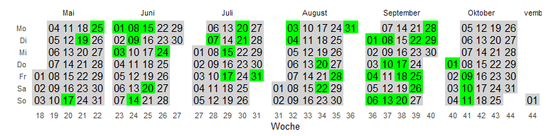

> Beobachtung: Der September war mit 14 Sessions der aktivste Segelmonat.

# Wochentage

Nun kann man den Datensatz nach den enthaltenen Variablen stratifizieren, beginnend mit dem Wochentag.

## Häufigkeitsverteilung

[interactive chart not shown]

> Beobachtung: Mittwochs scheint mir die große Känguruhregatta das Segeln zu vermiesen, bei der vereinsinternen Dienstagsregatta scheint ich jedoch gerne dabei zu sein. (Oder: Nach der Dienstagsregatta bin ich so durch, dass Mittwochs gar nichts geht?)

## Räumliche Verteilung

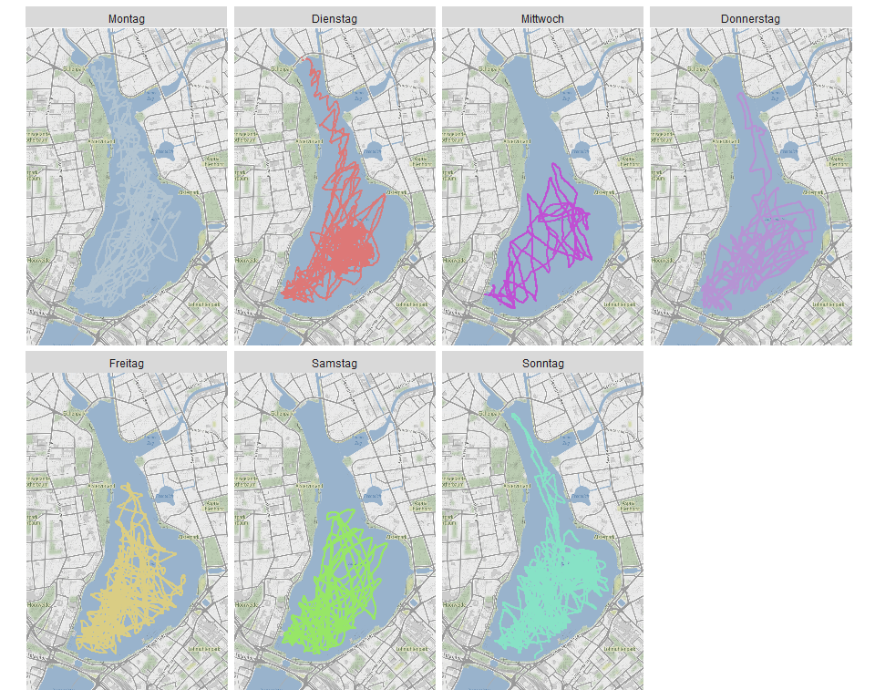

> Beobachtung: Mittwochs und Samstags wagt man sich anscheinend nicht so weit raus.

# Gefahrene Peilungen

Zu jedem GPS-Punkt ist die momentane Peilung bekannt (die “Fahrtrichtung”). Dies können wir auszählen und als Histogramm (Häufigkeitsdiagramm) wie eine Kompassrose darstellen:

[interactive chart not shown]

Der Kurs um 15° (Nord-Nordost) sowie 165° (Süd-Südost) scheint bei mir sehr beliebt zu sein. Schaut man sich die geografische Form der Alster an, ist dies unmittelbar einsichtig: Als langgestrecktes Nord-Süd-Revier fährt man eben mehr “hoch und runter” statt “rechts und links”, mit leichter Tendenz, zu Beginn “nach Nordost” zu fahren.

> Beobachtung: Der übliche Start-Weg vom OSG-Steg geht nach Nord-Nordost

# Bootstypen

## Häufigkeitsverteilung

[interactive chart not shown]

Mit 14 Sessions war Conger mein beliebtestes Boot. Dies lag zum einen daran, dass es ein sehr anfängerfreundliches Boot ist (ich habe meinen Segelschein erst Ende 2019 abgelegt und habe davor noch nie ein Segelboot betreten), der andere Grund findet sich in der Analyse der Segelpartner.

> Beobachtung: Auf Conger ist gut Segeln lernen

## Räumliche Verteilung

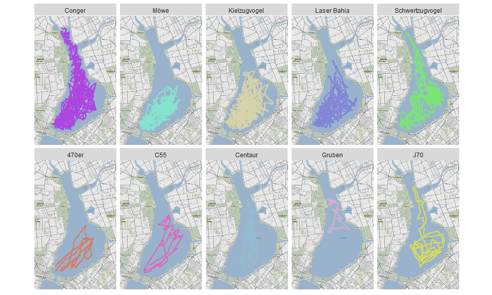

> Beobachtung: Mit Conger und Schwertzugvogel (Almar) kommt man überall hin, mit der Möwe bleibt man lieber nahe beim OSG-Steg.

# Segelpartner

## Häufigkeitsverteilung

[interactive chart not shown]

Mit 11 Sessions war ich allein am öftesten draußen. Dies lag vor allem an den Corona-bedingten Kontaktbeschränkungen im Mai und Juni 2020 - so musste ich gezwungenermaßen das Einhandsegeln erlernen.

## Räumliche Verteilung

[figure not shown]

> Beobachtung: Mit Erik und Leo kann man bis zur letzten Brücke fahren, mit Felix zur Alsterperle.

# Lieblings-Regionen auf der Alster

Achtung Bahnhof: Wir betrachten die zweidimensionale Dichte der Wegfunktion. Auf deutsch: Man kann die Alster in kleine Quadrate einteilen und zählen, wie oft jedes Quadrat durchfahren wurde. Die Quadrate färbe ich entsprechend der Häufigkeit ihres Durchfahrens ein - häufige durchfahrene Flächen rot, selten durchfahrene grün. So wie eine Corona-Hotspot-Karte eben.

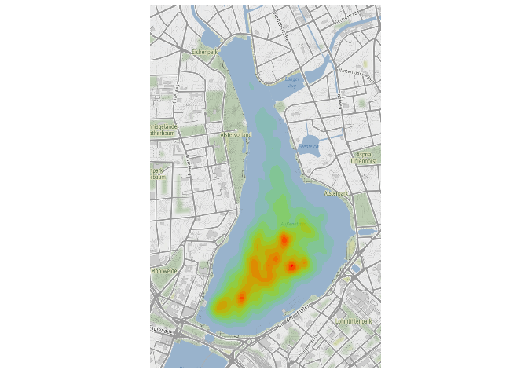

> Beobachtung: Die roten Hotspots könnten die Dienstagsregatta-Runden sein, der Vereinssteg unten links ist ebenfalls deutlich zu sehen.

# Anmerkungen, Limiterungen und Ausblick

- nicht alle Tracks habe ich mitgeschnitten (nur schätzungsweise 80%)
- außer den 175 Seemeilen auf der Alster bin ich im Jahr 220 noch 280 Seemeilen auf der Ostsee unterwegs gewesen - diese sind hier außen vor, wären allerdings eine eigene Analyse wert
- …

# Credits

Danke OSG für die tolle Gemeinschaft, die tollen Boote und die tollen Angebote!

# Technisches

Die Datensammlung erfolgt mit den Apps [Komoot](https://www.komoot.de/) und [Waterspeed](https://www.waterspeedapp.com/), diese Analyse wurde mit [R 4.0.2](https://www.r-project.org/) und folgenden nützlichen Helfern erstellt:

- Data Input:
  - `readr`
  - `readxl`
- Data Wrangling:
  - `dplyr`
  - `purrr`
  - `tidyr`
  - `lubridate`
  - `glue`
- Grafik:
  - `ggplot2`
  - `RColorBrewer`
  - `randomcoloR`
- Geoanalyse:
  - `ggmap`
  - `XML`
- Output:
  - `Rmarkdown`
  - `prettydoc`

Der Code für alle Berechnungen und Visualisierungen kann in meinem [Github Repository](https://github.com/shosaco/sailing_analyses) heruntergeladen werden, diese Seite ist unter https://shosaco.github.io/sailing_analyses/ erreichbar.